# Risk Factor Analysis

## Outcome Variable

**Outcome Variable:** haz

## Predictor Variables

**Intervention Variable:** mhtcm

**Adjustment Set:**

- arm
- W_mage
- meducyrs
- feducyrs
- hhwealth_quart
- single
- W_gagebrth
- W_birthwt
- W_birthlen
- vagbrth
- parity
- delta_W_mage
- delta_meducyrs
- delta_feducyrs
- delta_hhwealth_quart
- delta_single
- delta_W_gagebrth
- delta_W_birthwt
- delta_W_birthlen
- delta_vagbrth
- delta_parity

## Stratifying Variables

The analysis was stratified on these variable(s):

- agecat
- studyid
- country

## Data Summary

| agecat | studyid | country | mhtcm | n_cell | n | outcome_variable |
| --- | --- | --- | --- | --- | --- | --- |
| 6 months | ki0047075b-MAL-ED | BANGLADESH | >=155 cm | 24 | 241 | haz |
| 6 months | ki0047075b-MAL-ED | BANGLADESH | <151 cm | 156 | 241 | haz |
| 6 months | ki0047075b-MAL-ED | BANGLADESH | [151-155) cm | 61 | 241 | haz |
| 6 months | ki0047075b-MAL-ED | BRAZIL | >=155 cm | 121 | 209 | haz |
| 6 months | ki0047075b-MAL-ED | BRAZIL | <151 cm | 51 | 209 | haz |
| 6 months | ki0047075b-MAL-ED | BRAZIL | [151-155) cm | 37 | 209 | haz |
| 6 months | ki0047075b-MAL-ED | INDIA | >=155 cm | 55 | 235 | haz |
| 6 months | ki0047075b-MAL-ED | INDIA | <151 cm | 112 | 235 | haz |
| 6 months | ki0047075b-MAL-ED | INDIA | [151-155) cm | 68 | 235 | haz |
| 6 months | ki0047075b-MAL-ED | NEPAL | >=155 cm | 41 | 236 | haz |
| 6 months | ki0047075b-MAL-ED | NEPAL | <151 cm | 132 | 236 | haz |
| 6 months | ki0047075b-MAL-ED | NEPAL | [151-155) cm | 63 | 236 | haz |
| 6 months | ki0047075b-MAL-ED | PERU | >=155 cm | 58 | 272 | haz |
| 6 months | ki0047075b-MAL-ED | PERU | <151 cm | 157 | 272 | haz |
| 6 months | ki0047075b-MAL-ED | PERU | [151-155) cm | 57 | 272 | haz |
| 6 months | ki0047075b-MAL-ED | SOUTH AFRICA | >=155 cm | 187 | 249 | haz |
| 6 months | ki0047075b-MAL-ED | SOUTH AFRICA | <151 cm | 31 | 249 | haz |
| 6 months | ki0047075b-MAL-ED | SOUTH AFRICA | [151-155) cm | 31 | 249 | haz |
| 6 months | ki0047075b-MAL-ED | TANZANIA, UNITED REPUBLIC OF | >=155 cm | 147 | 247 | haz |
| 6 months | ki0047075b-MAL-ED | TANZANIA, UNITED REPUBLIC OF | <151 cm | 48 | 247 | haz |
| 6 months | ki0047075b-MAL-ED | TANZANIA, UNITED REPUBLIC OF | [151-155) cm | 52 | 247 | haz |
| 6 months | ki1000304b-SAS-CompFeed | INDIA | >=155 cm | 510 | 1228 | haz |
| 6 months | ki1000304b-SAS-CompFeed | INDIA | <151 cm | 421 | 1228 | haz |
| 6 months | ki1000304b-SAS-CompFeed | INDIA | [151-155) cm | 297 | 1228 | haz |
| 6 months | ki1000304b-SAS-FoodSuppl | INDIA | >=155 cm | 74 | 379 | haz |
| 6 months | ki1000304b-SAS-FoodSuppl | INDIA | <151 cm | 202 | 379 | haz |
| 6 months | ki1000304b-SAS-FoodSuppl | INDIA | [151-155) cm | 103 | 379 | haz |
| 6 months | ki1017093-NIH-Birth | BANGLADESH | >=155 cm | 96 | 537 | haz |
| 6 months | ki1017093-NIH-Birth | BANGLADESH | <151 cm | 311 | 537 | haz |
| 6 months | ki1017093-NIH-Birth | BANGLADESH | [151-155) cm | 130 | 537 | haz |

[output cut: 93 more lines]

The following strata were considered:

- agecat: 24 months, studyid: ki0047075b-MAL-ED, country: BANGLADESH
- agecat: 24 months, studyid: ki0047075b-MAL-ED, country: BRAZIL
- agecat: 24 months, studyid: ki0047075b-MAL-ED, country: INDIA
- agecat: 24 months, studyid: ki0047075b-MAL-ED, country: NEPAL
- agecat: 24 months, studyid: ki0047075b-MAL-ED, country: PERU
- agecat: 24 months, studyid: ki0047075b-MAL-ED, country: SOUTH AFRICA
- agecat: 24 months, studyid: ki0047075b-MAL-ED, country: TANZANIA, UNITED REPUBLIC OF
- agecat: 24 months, studyid: ki1017093-NIH-Birth, country: BANGLADESH
- agecat: 24 months, studyid: ki1017093b-PROVIDE, country: BANGLADESH
- agecat: 24 months, studyid: ki1017093c-NIH-Crypto, country: BANGLADESH
- agecat: 24 months, studyid: ki1066203-TanzaniaChild2, country: TANZANIA, UNITED REPUBLIC OF
- agecat: 24 months, studyid: ki1101329-Keneba, country: GAMBIA
- agecat: 24 months, studyid: ki1119695-PROBIT, country: BELARUS
- agecat: 24 months, studyid: ki1126311-ZVITAMBO, country: ZIMBABWE
- agecat: 24 months, studyid: ki1135781-COHORTS, country: GUATEMALA
- agecat: 24 months, studyid: ki1135781-COHORTS, country: INDIA
- agecat: 24 months, studyid: ki1135781-COHORTS, country: PHILIPPINES
- agecat: 24 months, studyid: ki1148112-LCNI-5, country: MALAWI
- agecat: 24 months, studyid: kiGH5241-JiVitA-3, country: BANGLADESH
- agecat: 6 months, studyid: ki0047075b-MAL-ED, country: BANGLADESH
- agecat: 6 months, studyid: ki0047075b-MAL-ED, country: BRAZIL
- agecat: 6 months, studyid: ki0047075b-MAL-ED, country: INDIA
- agecat: 6 months, studyid: ki0047075b-MAL-ED, country: NEPAL
- agecat: 6 months, studyid: ki0047075b-MAL-ED, country: PERU
- agecat: 6 months, studyid: ki0047075b-MAL-ED, country: SOUTH AFRICA
- agecat: 6 months, studyid: ki0047075b-MAL-ED, country: TANZANIA, UNITED REPUBLIC OF
- agecat: 6 months, studyid: ki1000304b-SAS-CompFeed, country: INDIA
- agecat: 6 months, studyid: ki1000304b-SAS-FoodSuppl, country: INDIA
- agecat: 6 months, studyid: ki1017093-NIH-Birth, country: BANGLADESH
- agecat: 6 months, studyid: ki1017093b-PROVIDE, country: BANGLADESH
- agecat: 6 months, studyid: ki1017093c-NIH-Crypto, country: BANGLADESH
- agecat: 6 months, studyid: ki1066203-TanzaniaChild2, country: TANZANIA, UNITED REPUBLIC OF
- agecat: 6 months, studyid: ki1101329-Keneba, country: GAMBIA
- agecat: 6 months, studyid: ki1112895-Guatemala BSC, country: GUATEMALA
- agecat: 6 months, studyid: ki1119695-PROBIT, country: BELARUS
- agecat: 6 months, studyid: ki1126311-ZVITAMBO, country: ZIMBABWE
- agecat: 6 months, studyid: ki1135781-COHORTS, country: GUATEMALA
- agecat: 6 months, studyid: ki1135781-COHORTS, country: INDIA
- agecat: 6 months, studyid: ki1135781-COHORTS, country: PHILIPPINES
- agecat: 6 months, studyid: ki1148112-LCNI-5, country: MALAWI
- agecat: 6 months, studyid: kiGH5241-JiVitA-3, country: BANGLADESH

### Dropped Strata

Some strata were dropped due to rare outcomes:

- agecat: 24 months, studyid: ki1066203-TanzaniaChild2, country: TANZANIA, UNITED REPUBLIC OF

## Methods Detail

We’re interested in the causal parameters $E[Y_a]$ for all values of $a \in \mathcal{A}$. These parameters represent the mean outcome if, possibly contrary to fact, we intervened to set all units to have $A=a$. Under the randomization and positivity assumptions, these are identified by the statistical parameters $\psi_a=E_W[E_{Y|A,W}(Y|A=a,W)]$. In addition, we’re interested in the mean of $Y$, $E[Y]$ under no intervention (the observed mean). We will estimate these parameters by using SuperLearner to fit the relevant likelihood factors – $E_{Y|A,W}(Y|A=a,W)$ and $p(A=a|W)$, and then updating our likelihood fit using a joint TMLE.

For unadjusted analyses ($W=\{\}$), initial likelihoods were estimated using Lrnr_glm to estimate the simple $E(Y|A)$ and Lrnr_mean to estimate $p(A)$. For adjusted analyses, a small library containing Lrnr_glmnet, Lrnr_xgboost, and Lrnr_mean was used.

Having estimated these parameters, we will then use the delta method to estimate relative risks and attributable risks relative to a prespecified baseline level of $A$.

# Results Detail

## Results Plots

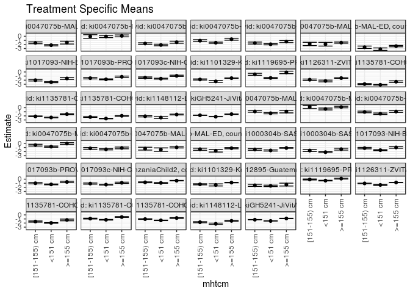

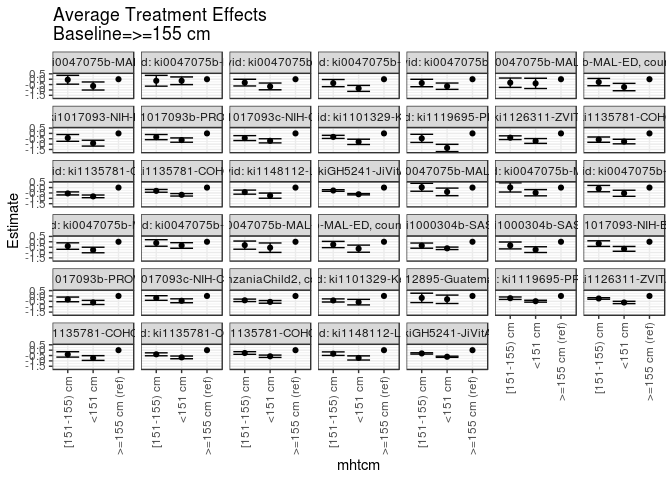

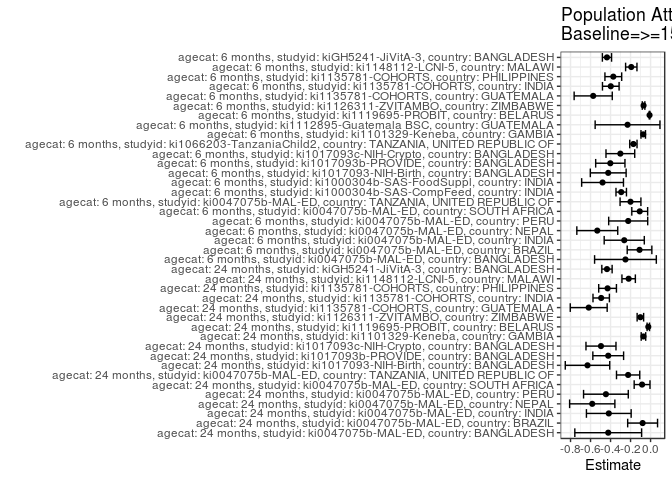

## Results Table

### Parameter: TSM

| agecat | studyid | country | intervention_level | baseline_level | estimate | ci_lower | ci_upper |
| --- | --- | --- | --- | --- | --- | --- | --- |
| 6 months | ki0047075b-MAL-ED | BANGLADESH | >=155 cm | NA | -0.9539503 | -1.2706251 | -0.6372756 |
| 6 months | ki0047075b-MAL-ED | BANGLADESH | <151 cm | NA | -1.3540627 | -1.5054499 | -1.2026756 |
| 6 months | ki0047075b-MAL-ED | BANGLADESH | [151-155) cm | NA | -0.9233619 | -1.1170009 | -0.7297230 |
| 6 months | ki0047075b-MAL-ED | BRAZIL | >=155 cm | NA | 0.1579249 | -0.0302196 | 0.3460694 |
| 6 months | ki0047075b-MAL-ED | BRAZIL | <151 cm | NA | -0.3196609 | -0.5435506 | -0.0957712 |
| 6 months | ki0047075b-MAL-ED | BRAZIL | [151-155) cm | NA | 0.1719479 | -0.2137817 | 0.5576774 |
| 6 months | ki0047075b-MAL-ED | INDIA | >=155 cm | NA | -0.9428276 | -1.1602787 | -0.7253765 |
| 6 months | ki0047075b-MAL-ED | INDIA | <151 cm | NA | -1.4715517 | -1.6510422 | -1.2920612 |
| 6 months | ki0047075b-MAL-ED | INDIA | [151-155) cm | NA | -1.0351131 | -1.2320814 | -0.8381448 |
| 6 months | ki0047075b-MAL-ED | NEPAL | >=155 cm | NA | -0.0289073 | -0.2388611 | 0.1810466 |
| 6 months | ki0047075b-MAL-ED | NEPAL | <151 cm | NA | -0.7920073 | -0.9395417 | -0.6444729 |
| 6 months | ki0047075b-MAL-ED | NEPAL | [151-155) cm | NA | -0.4277584 | -0.6433058 | -0.2122110 |
| 6 months | ki0047075b-MAL-ED | PERU | >=155 cm | NA | -1.1004606 | -1.3139700 | -0.8869513 |
| 6 months | ki0047075b-MAL-ED | PERU | <151 cm | NA | -1.4441692 | -1.5928223 | -1.2955161 |
| 6 months | ki0047075b-MAL-ED | PERU | [151-155) cm | NA | -1.2099184 | -1.4261328 | -0.9937041 |
| 6 months | ki0047075b-MAL-ED | SOUTH AFRICA | >=155 cm | NA | -0.9643601 | -1.1097496 | -0.8189705 |
| 6 months | ki0047075b-MAL-ED | SOUTH AFRICA | <151 cm | NA | -1.5144873 | -1.9277416 | -1.1012330 |
| 6 months | ki0047075b-MAL-ED | SOUTH AFRICA | [151-155) cm | NA | -1.2774289 | -1.6283346 | -0.9265232 |
| 6 months | ki0047075b-MAL-ED | TANZANIA, UNITED REPUBLIC OF | >=155 cm | NA | -1.1680815 | -1.3168716 | -1.0192914 |
| 6 months | ki0047075b-MAL-ED | TANZANIA, UNITED REPUBLIC OF | <151 cm | NA | -1.8088188 | -2.1075880 | -1.5100495 |
| 6 months | ki0047075b-MAL-ED | TANZANIA, UNITED REPUBLIC OF | [151-155) cm | NA | -1.4229750 | -1.6747556 | -1.1711944 |
| 6 months | ki1000304b-SAS-CompFeed | INDIA | >=155 cm | NA | -1.1135454 | -1.1956346 | -1.0314562 |
| 6 months | ki1000304b-SAS-CompFeed | INDIA | <151 cm | NA | -1.7229004 | -1.8592106 | -1.5865903 |
| 6 months | ki1000304b-SAS-CompFeed | INDIA | [151-155) cm | NA | -1.4704259 | -1.6762904 | -1.2645613 |
| 6 months | ki1000304b-SAS-FoodSuppl | INDIA | >=155 cm | NA | -1.4083732 | -1.6336308 | -1.1831156 |
| 6 months | ki1000304b-SAS-FoodSuppl | INDIA | <151 cm | NA | -2.1405372 | -2.2846211 | -1.9964533 |
| 6 months | ki1000304b-SAS-FoodSuppl | INDIA | [151-155) cm | NA | -1.7485532 | -1.9767956 | -1.5203109 |
| 6 months | ki1017093-NIH-Birth | BANGLADESH | >=155 cm | NA | -0.9840807 | -1.1821223 | -0.7860391 |
| 6 months | ki1017093-NIH-Birth | BANGLADESH | <151 cm | NA | -1.6436430 | -1.7517752 | -1.5355107 |
| 6 months | ki1017093-NIH-Birth | BANGLADESH | [151-155) cm | NA | -1.1537426 | -1.3275378 | -0.9799474 |

[output cut: 90 more lines]

### Parameter: E(Y)

| agecat | studyid | country | intervention_level | baseline_level | estimate | ci_lower | ci_upper |
| --- | --- | --- | --- | --- | --- | --- | --- |
| 6 months | ki0047075b-MAL-ED | BANGLADESH | NA | NA | -1.2049931 | -1.3222136 | -1.0877726 |
| 6 months | ki0047075b-MAL-ED | BRAZIL | NA | NA | 0.0475758 | -0.0963508 | 0.1915023 |
| 6 months | ki0047075b-MAL-ED | INDIA | NA | NA | -1.2059574 | -1.3243030 | -1.0876119 |
| 6 months | ki0047075b-MAL-ED | NEPAL | NA | NA | -0.5615819 | -0.6741832 | -0.4489807 |
| 6 months | ki0047075b-MAL-ED | PERU | NA | NA | -1.3241023 | -1.4325083 | -1.2156964 |
| 6 months | ki0047075b-MAL-ED | SOUTH AFRICA | NA | NA | -1.0727443 | -1.2024880 | -0.9430006 |
| 6 months | ki0047075b-MAL-ED | TANZANIA, UNITED REPUBLIC OF | NA | NA | -1.3687449 | -1.4907629 | -1.2467270 |
| 6 months | ki1000304b-SAS-CompFeed | INDIA | NA | NA | -1.4068893 | -1.4981242 | -1.3156543 |
| 6 months | ki1000304b-SAS-FoodSuppl | INDIA | NA | NA | -1.8882058 | -1.9998264 | -1.7765852 |
| 6 months | ki1017093-NIH-Birth | BANGLADESH | NA | NA | -1.4073821 | -1.4960598 | -1.3187043 |
| 6 months | ki1017093b-PROVIDE | BANGLADESH | NA | NA | -1.0895301 | -1.1639589 | -1.0151013 |
| 6 months | ki1017093c-NIH-Crypto | BANGLADESH | NA | NA | -1.1986783 | -1.2700937 | -1.1272630 |
| 6 months | ki1066203-TanzaniaChild2 | TANZANIA, UNITED REPUBLIC OF | NA | NA | -0.5424553 | -0.5916933 | -0.4932174 |
| 6 months | ki1101329-Keneba | GAMBIA | NA | NA | -0.9159303 | -0.9650776 | -0.8667830 |
| 6 months | ki1112895-Guatemala BSC | GUATEMALA | NA | NA | -1.5599206 | -1.6885363 | -1.4313049 |
| 6 months | ki1119695-PROBIT | BELARUS | NA | NA | 0.1157811 | 0.0226850 | 0.2088772 |
| 6 months | ki1126311-ZVITAMBO | ZIMBABWE | NA | NA | -0.8803077 | -0.9076731 | -0.8529423 |
| 6 months | ki1135781-COHORTS | GUATEMALA | NA | NA | -1.8116225 | -1.8800533 | -1.7431916 |
| 6 months | ki1135781-COHORTS | INDIA | NA | NA | -0.9254151 | -0.9779952 | -0.8728349 |
| 6 months | ki1135781-COHORTS | PHILIPPINES | NA | NA | -1.1405724 | -1.1824954 | -1.0986493 |
| 6 months | ki1148112-LCNI-5 | MALAWI | NA | NA | -1.6577751 | -1.7275296 | -1.5880207 |
| 6 months | kiGH5241-JiVitA-3 | BANGLADESH | NA | NA | -1.3139055 | -1.3370256 | -1.2907854 |
| 24 months | ki0047075b-MAL-ED | BANGLADESH | NA | NA | -1.9783962 | -2.1050210 | -1.8517715 |
| 24 months | ki0047075b-MAL-ED | BRAZIL | NA | NA | 0.0061144 | -0.1625850 | 0.1748138 |
| 24 months | ki0047075b-MAL-ED | INDIA | NA | NA | -1.8844690 | -2.0097879 | -1.7591502 |
| 24 months | ki0047075b-MAL-ED | NEPAL | NA | NA | -1.3075877 | -1.4270718 | -1.1881037 |
| 24 months | ki0047075b-MAL-ED | PERU | NA | NA | -1.7524710 | -1.8736426 | -1.6312994 |
| 24 months | ki0047075b-MAL-ED | SOUTH AFRICA | NA | NA | -1.6432229 | -1.7795844 | -1.5068615 |
| 24 months | ki0047075b-MAL-ED | TANZANIA, UNITED REPUBLIC OF | NA | NA | -2.6455607 | -2.7807256 | -2.5103959 |
| 24 months | ki1017093-NIH-Birth | BANGLADESH | NA | NA | -2.2190579 | -2.3217459 | -2.1163699 |
| 24 months | ki1017093b-PROVIDE | BANGLADESH | NA | NA | -1.6002600 | -1.6836163 | -1.5169036 |
| 24 months | ki1017093c-NIH-Crypto | BANGLADESH | NA | NA | -1.4412646 | -1.5249156 | -1.3576135 |
| 24 months | ki1101329-Keneba | GAMBIA | NA | NA | -1.5829641 | -1.6348134 | -1.5311148 |
| 24 months | ki1119695-PROBIT | BELARUS | NA | NA | -0.1322181 | -0.4300523 | 0.1656161 |
| 24 months | ki1126311-ZVITAMBO | ZIMBABWE | NA | NA | -1.5981623 | -1.6603107 | -1.5360139 |
| 24 months | ki1135781-COHORTS | GUATEMALA | NA | NA | -2.9963380 | -3.0630990 | -2.9295770 |
| 24 months | ki1135781-COHORTS | INDIA | NA | NA | -2.0710720 | -2.1255079 | -2.0166362 |
| 24 months | ki1135781-COHORTS | PHILIPPINES | NA | NA | -2.4141145 | -2.4590818 | -2.3691473 |
| 24 months | ki1148112-LCNI-5 | MALAWI | NA | NA | -1.8851820 | -1.9664818 | -1.8038822 |
| 24 months | kiGH5241-JiVitA-3 | BANGLADESH | NA | NA | -2.0137632 | -2.0415122 | -1.9860142 |

### Parameter: ATE

| agecat | studyid | country | intervention_level | baseline_level | estimate | ci_lower | ci_upper |
| --- | --- | --- | --- | --- | --- | --- | --- |
| 6 months | ki0047075b-MAL-ED | BANGLADESH | >=155 cm | >=155 cm | 0.0000000 | 0.0000000 | 0.0000000 |
| 6 months | ki0047075b-MAL-ED | BANGLADESH | <151 cm | >=155 cm | -0.4001124 | -0.7518200 | -0.0484048 |
| 6 months | ki0047075b-MAL-ED | BANGLADESH | [151-155) cm | >=155 cm | 0.0305884 | -0.3411171 | 0.4022939 |
| 6 months | ki0047075b-MAL-ED | BRAZIL | >=155 cm | >=155 cm | 0.0000000 | 0.0000000 | 0.0000000 |
| 6 months | ki0047075b-MAL-ED | BRAZIL | <151 cm | >=155 cm | -0.4775859 | -0.7687294 | -0.1864423 |
| 6 months | ki0047075b-MAL-ED | BRAZIL | [151-155) cm | >=155 cm | 0.0140229 | -0.4144434 | 0.4424892 |
| 6 months | ki0047075b-MAL-ED | INDIA | >=155 cm | >=155 cm | 0.0000000 | 0.0000000 | 0.0000000 |
| 6 months | ki0047075b-MAL-ED | INDIA | <151 cm | >=155 cm | -0.5287241 | -0.8118331 | -0.2456151 |
| 6 months | ki0047075b-MAL-ED | INDIA | [151-155) cm | >=155 cm | -0.0922855 | -0.3870931 | 0.2025221 |
| 6 months | ki0047075b-MAL-ED | NEPAL | >=155 cm | >=155 cm | 0.0000000 | 0.0000000 | 0.0000000 |
| 6 months | ki0047075b-MAL-ED | NEPAL | <151 cm | >=155 cm | -0.7631000 | -1.0207919 | -0.5054082 |
| 6 months | ki0047075b-MAL-ED | NEPAL | [151-155) cm | >=155 cm | -0.3988511 | -0.7005939 | -0.0971083 |
| 6 months | ki0047075b-MAL-ED | PERU | >=155 cm | >=155 cm | 0.0000000 | 0.0000000 | 0.0000000 |
| 6 months | ki0047075b-MAL-ED | PERU | <151 cm | >=155 cm | -0.3437085 | -0.6030432 | -0.0843739 |
| 6 months | ki0047075b-MAL-ED | PERU | [151-155) cm | >=155 cm | -0.1094578 | -0.4127000 | 0.1937845 |
| 6 months | ki0047075b-MAL-ED | SOUTH AFRICA | >=155 cm | >=155 cm | 0.0000000 | 0.0000000 | 0.0000000 |
| 6 months | ki0047075b-MAL-ED | SOUTH AFRICA | <151 cm | >=155 cm | -0.5501272 | -0.9883724 | -0.1118821 |
| 6 months | ki0047075b-MAL-ED | SOUTH AFRICA | [151-155) cm | >=155 cm | -0.3130688 | -0.6932807 | 0.0671431 |
| 6 months | ki0047075b-MAL-ED | TANZANIA, UNITED REPUBLIC OF | >=155 cm | >=155 cm | 0.0000000 | 0.0000000 | 0.0000000 |
| 6 months | ki0047075b-MAL-ED | TANZANIA, UNITED REPUBLIC OF | <151 cm | >=155 cm | -0.6407372 | -0.9736681 | -0.3078064 |
| 6 months | ki0047075b-MAL-ED | TANZANIA, UNITED REPUBLIC OF | [151-155) cm | >=155 cm | -0.2548935 | -0.5458272 | 0.0360403 |
| 6 months | ki1000304b-SAS-CompFeed | INDIA | >=155 cm | >=155 cm | 0.0000000 | 0.0000000 | 0.0000000 |
| 6 months | ki1000304b-SAS-CompFeed | INDIA | <151 cm | >=155 cm | -0.6093550 | -0.7228785 | -0.4958316 |
| 6 months | ki1000304b-SAS-CompFeed | INDIA | [151-155) cm | >=155 cm | -0.3568805 | -0.5981691 | -0.1155919 |
| 6 months | ki1000304b-SAS-FoodSuppl | INDIA | >=155 cm | >=155 cm | 0.0000000 | 0.0000000 | 0.0000000 |
| 6 months | ki1000304b-SAS-FoodSuppl | INDIA | <151 cm | >=155 cm | -0.7321639 | -0.9995017 | -0.4648262 |
| 6 months | ki1000304b-SAS-FoodSuppl | INDIA | [151-155) cm | >=155 cm | -0.3401800 | -0.6607028 | -0.0196571 |
| 6 months | ki1017093-NIH-Birth | BANGLADESH | >=155 cm | >=155 cm | 0.0000000 | 0.0000000 | 0.0000000 |
| 6 months | ki1017093-NIH-Birth | BANGLADESH | <151 cm | >=155 cm | -0.6595622 | -0.8828424 | -0.4362820 |
| 6 months | ki1017093-NIH-Birth | BANGLADESH | [151-155) cm | >=155 cm | -0.1696618 | -0.4305940 | 0.0912703 |

[output cut: 90 more lines]

### Parameter: PAR

| agecat | studyid | country | intervention_level | baseline_level | estimate | ci_lower | ci_upper |
| --- | --- | --- | --- | --- | --- | --- | --- |
| 6 months | ki0047075b-MAL-ED | BANGLADESH | >=155 cm | NA | -0.2510428 | -0.5596089 | 0.0575234 |
| 6 months | ki0047075b-MAL-ED | BRAZIL | >=155 cm | NA | -0.1103492 | -0.2335285 | 0.0128301 |
| 6 months | ki0047075b-MAL-ED | INDIA | >=155 cm | NA | -0.2631299 | -0.4635970 | -0.0626627 |
| 6 months | ki0047075b-MAL-ED | NEPAL | >=155 cm | NA | -0.5326747 | -0.7371156 | -0.3282337 |
| 6 months | ki0047075b-MAL-ED | PERU | >=155 cm | NA | -0.2236417 | -0.4186625 | -0.0286208 |
| 6 months | ki0047075b-MAL-ED | SOUTH AFRICA | >=155 cm | NA | -0.1083843 | -0.1876014 | -0.0291671 |
| 6 months | ki0047075b-MAL-ED | TANZANIA, UNITED REPUBLIC OF | >=155 cm | NA | -0.2006634 | -0.3048332 | -0.0964936 |
| 6 months | ki1000304b-SAS-CompFeed | INDIA | >=155 cm | NA | -0.2933439 | -0.3457047 | -0.2409831 |
| 6 months | ki1000304b-SAS-FoodSuppl | INDIA | >=155 cm | NA | -0.4798326 | -0.6887481 | -0.2709171 |
| 6 months | ki1017093-NIH-Birth | BANGLADESH | >=155 cm | NA | -0.4233013 | -0.6022403 | -0.2443624 |
| 6 months | ki1017093b-PROVIDE | BANGLADESH | >=155 cm | NA | -0.4023871 | -0.5487096 | -0.2560647 |
| 6 months | ki1017093c-NIH-Crypto | BANGLADESH | >=155 cm | NA | -0.3020585 | -0.4456502 | -0.1584669 |
| 6 months | ki1066203-TanzaniaChild2 | TANZANIA, UNITED REPUBLIC OF | >=155 cm | NA | -0.1717343 | -0.2081858 | -0.1352828 |
| 6 months | ki1101329-Keneba | GAMBIA | >=155 cm | NA | -0.0733110 | -0.0959057 | -0.0507163 |
| 6 months | ki1112895-Guatemala BSC | GUATEMALA | >=155 cm | NA | -0.2300465 | -0.5540033 | 0.0939103 |
| 6 months | ki1119695-PROBIT | BELARUS | >=155 cm | NA | -0.0101852 | -0.0139010 | -0.0064693 |
| 6 months | ki1126311-ZVITAMBO | ZIMBABWE | >=155 cm | NA | -0.0699137 | -0.0828718 | -0.0569555 |
| 6 months | ki1135781-COHORTS | GUATEMALA | >=155 cm | NA | -0.5734607 | -0.7640167 | -0.3829048 |
| 6 months | ki1135781-COHORTS | INDIA | >=155 cm | NA | -0.3977165 | -0.4808257 | -0.3146074 |
| 6 months | ki1135781-COHORTS | PHILIPPINES | >=155 cm | NA | -0.3724330 | -0.4562180 | -0.2886481 |
| 6 months | ki1148112-LCNI-5 | MALAWI | >=155 cm | NA | -0.1927817 | -0.2495318 | -0.1360316 |
| 6 months | kiGH5241-JiVitA-3 | BANGLADESH | >=155 cm | NA | -0.4357997 | -0.4817328 | -0.3898665 |
| 24 months | ki0047075b-MAL-ED | BANGLADESH | >=155 cm | NA | -0.4232143 | -0.7571210 | -0.0893075 |
| 24 months | ki0047075b-MAL-ED | BRAZIL | >=155 cm | NA | -0.0794685 | -0.2288194 | 0.0698825 |
| 24 months | ki0047075b-MAL-ED | INDIA | >=155 cm | NA | -0.4175595 | -0.6410693 | -0.1940498 |
| 24 months | ki0047075b-MAL-ED | NEPAL | >=155 cm | NA | -0.5830445 | -0.8092247 | -0.3568642 |
| 24 months | ki0047075b-MAL-ED | PERU | >=155 cm | NA | -0.4462968 | -0.6698429 | -0.2227507 |
| 24 months | ki0047075b-MAL-ED | SOUTH AFRICA | >=155 cm | NA | -0.0847934 | -0.1638733 | -0.0057134 |
| 24 months | ki0047075b-MAL-ED | TANZANIA, UNITED REPUBLIC OF | >=155 cm | NA | -0.2243539 | -0.3405309 | -0.1081770 |
| 24 months | ki1017093-NIH-Birth | BANGLADESH | >=155 cm | NA | -0.6304526 | -0.8526571 | -0.4082482 |
| 24 months | ki1017093b-PROVIDE | BANGLADESH | >=155 cm | NA | -0.4233114 | -0.5770462 | -0.2695765 |
| 24 months | ki1017093c-NIH-Crypto | BANGLADESH | >=155 cm | NA | -0.4957084 | -0.6456955 | -0.3457213 |
| 24 months | ki1101329-Keneba | GAMBIA | >=155 cm | NA | -0.0711256 | -0.0935769 | -0.0486743 |
| 24 months | ki1119695-PROBIT | BELARUS | >=155 cm | NA | -0.0226017 | -0.0347872 | -0.0104161 |
| 24 months | ki1126311-ZVITAMBO | ZIMBABWE | >=155 cm | NA | -0.1018138 | -0.1342621 | -0.0693655 |
| 24 months | ki1135781-COHORTS | GUATEMALA | >=155 cm | NA | -0.6183077 | -0.8028040 | -0.4338114 |
| 24 months | ki1135781-COHORTS | INDIA | >=155 cm | NA | -0.4935577 | -0.5755543 | -0.4115611 |
| 24 months | ki1135781-COHORTS | PHILIPPINES | >=155 cm | NA | -0.4297597 | -0.5184149 | -0.3411044 |
| 24 months | ki1148112-LCNI-5 | MALAWI | >=155 cm | NA | -0.2190863 | -0.2861786 | -0.1519940 |
| 24 months | kiGH5241-JiVitA-3 | BANGLADESH | >=155 cm | NA | -0.4357555 | -0.4872660 | -0.3842450 |